# TempDisc

Kendra Seaman

July 07, 2020

# Temporal Discounting Social Distancing Study 2

# Domain (Money x Health x Social) ANCOVA with Age

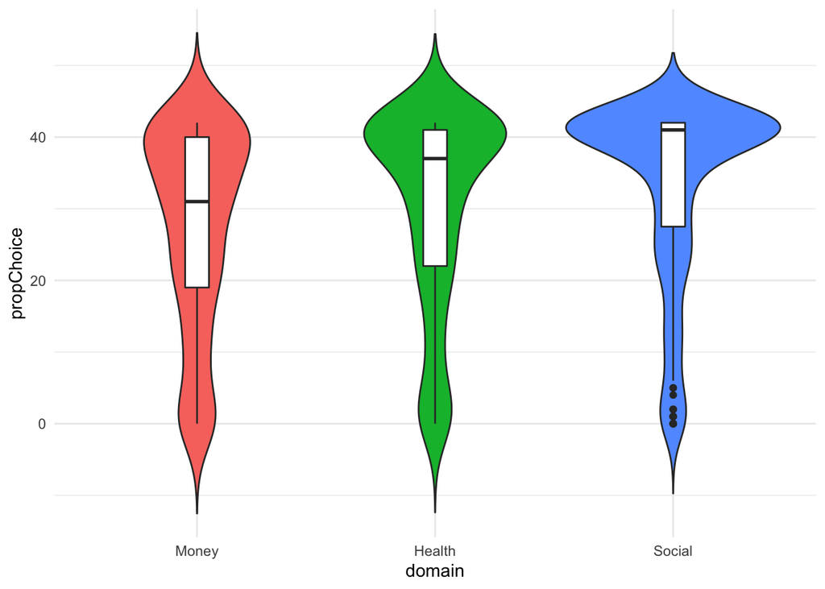

Effect

DFn

DFd

F

p

p<.05

ges

Age

1

241

15.554

0.000105

0.040

domain

2

482

23.509

0.000000

0.033

Age:domain

2

482

3.628

0.027000

0.005

### Sphericity check

Effect

W

p

p<.05

domain

0.968

0.021

Age:domain

0.968

0.021

### Sphericity correction

Effect

GGe

DF[GG]

p[GG]

p[GG]<.05

HFe

DF[HF]

p[HF]

p[HF]<.05

domain

0.969

1.94, 467.16

0.000

0.977

1.95, 470.89

0.000

Age:domain

0.969

1.94, 467.16

0.029

0.977

1.95, 470.89

0.028

### Follow-up Test

| .y. | group1 | group2 | n1 | n2 | statistic | df | p | p.adj | p.adj.signif |
| --- | --- | --- | --- | --- | --- | --- | --- | --- | --- |
| propChoice | Money | Health | 243 | 243 | -3.414696 | 242 | 0.000749 | 0.002000 | ** |
| propChoice | Money | Social | 243 | 243 | -6.336925 | 242 | 0.000000 | 0.000000 | **** |
| propChoice | Health | Social | 243 | 243 | -3.716263 | 242 | 0.000251 | 0.000753 | *** |

# Age effects

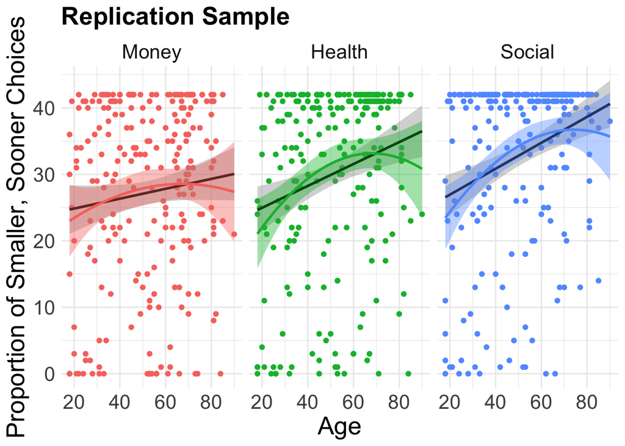

### Money

Model - Age

|  | Estimate | Std. Error | t value | Pr(>\|t\|) |
| --- | --- | --- | --- | --- |
| (Intercept) | -0.2179321 | 0.0650103 | -3.352272 | 0.0009305 |
| Age | 0.1012514 | 0.0650549 | 1.556400 | 0.1209253 |

Model - Age + Age^2

|  | Estimate | Std. Error | t value | Pr(>\|t\|) |
| --- | --- | --- | --- | --- |
| (Intercept) | -0.1596252 | 0.0951842 | -1.6770129 | 0.0948419 |
| Age | 0.0951540 | 0.0654992 | 1.4527507 | 0.1475992 |
| Age2 | -0.0583870 | 0.0695829 | -0.8390993 | 0.4022486 |

No efffect of age on money discounting.

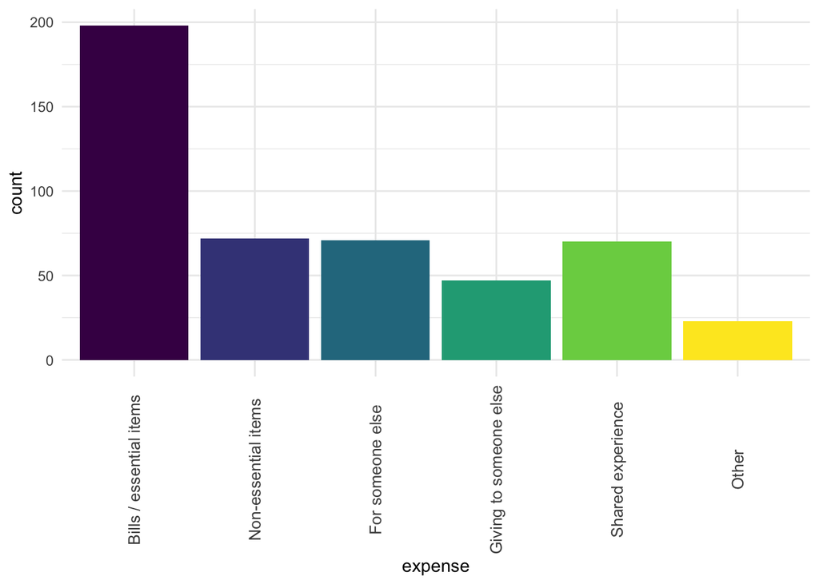

Q2169_1 = How important is getting more money, social contact, or health improvement to you right now? - Money

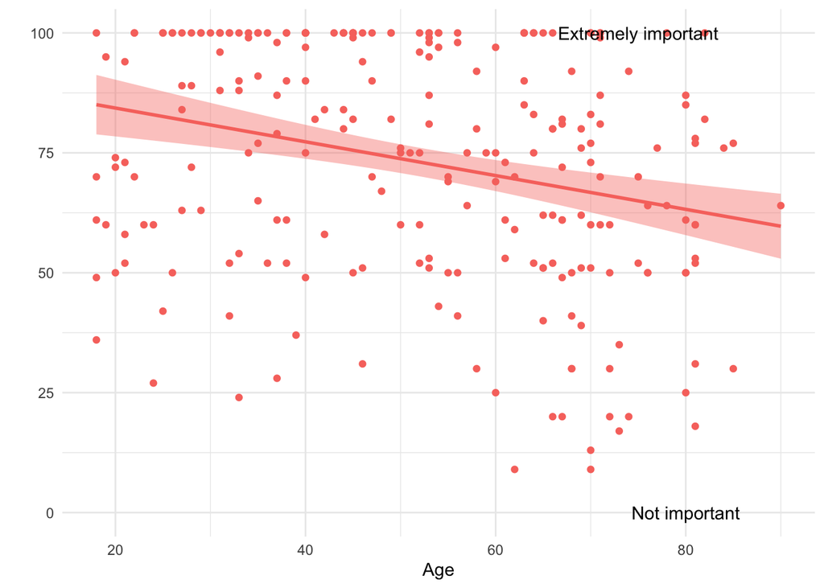

Correlation between age and importance of money, r(243) = -0.269, 95% CI [-0.382, -0.148], p = 0.

### Health

Model - Age

|  | Estimate | Std. Error | t value | Pr(>\|t\|) |
| --- | --- | --- | --- | --- |
| (Intercept) | 0.0011017 | 0.0629334 | 0.0175055 | 0.9860479 |
| Age | 0.2242792 | 0.0629767 | 3.5613072 | 0.0004446 |

Model - Age + Age^2

|  | Estimate | Std. Error | t value | Pr(>\|t\|) |
| --- | --- | --- | --- | --- |
| (Intercept) | 0.1234405 | 0.0916423 | 1.346981 | 0.1792567 |
| Age | 0.2114857 | 0.0630619 | 3.353620 | 0.0009268 |
| Age2 | -0.1225069 | 0.0669937 | -1.828634 | 0.0686956 |

Model comparison

| Res.Df | RSS | Df | Sum of Sq | F | Pr(>F) |
| --- | --- | --- | --- | --- | --- |
| 241 | 231.9457 | NA | NA | NA | NA |
| 240 | 228.7585 | 1 | 3.187273 | 3.343901 | 0.0686956 |

Significant linear effect of age on health discounting, with older adults discounting more than younger adults.

Q2169_2 = How important is getting more money, social contact, or health improvement to you right now? - Social contact

Mean importance of social contact is 89.0617284 [86.8756963, 91.2477605] on a scale from 0 (Not important) to 100 (Extremely important)

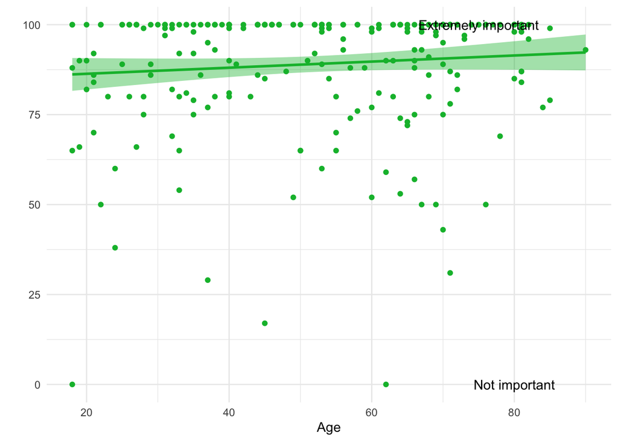

### Social

Model - Age

|  | Estimate | Std. Error | t value | Pr(>\|t\|) |
| --- | --- | --- | --- | --- |
| (Intercept) | 0.2168304 | 0.0575234 | 3.769429 | 0.0002058 |
| Age | 0.2654994 | 0.0575629 | 4.612336 | 0.0000065 |

Model - Age + Age^2

|  | Estimate | Std. Error | t value | Pr(>\|t\|) |
| --- | --- | --- | --- | --- |
| (Intercept) | 0.3230643 | 0.0838212 | 3.854208 | 0.0001491 |
| Age | 0.2543901 | 0.0576799 | 4.410373 | 0.0000156 |
| Age2 | -0.1063799 | 0.0612762 | -1.736072 | 0.0838344 |

Model comparison

| Res.Df | RSS | Df | Sum of Sq | F | Pr(>F) |
| --- | --- | --- | --- | --- | --- |
| 241 | 193.7816 | NA | NA | NA | NA |
| 240 | 191.3782 | 1 | 2.403349 | 3.013947 | 0.0838344 |

# Who are the social partners?

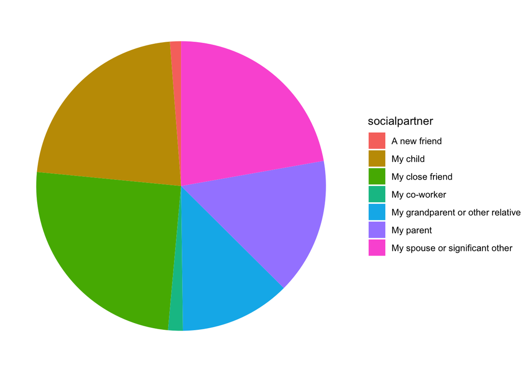

Q2169_3 = How important is getting more money, social contact, or health improvement to you right now? - Personal health

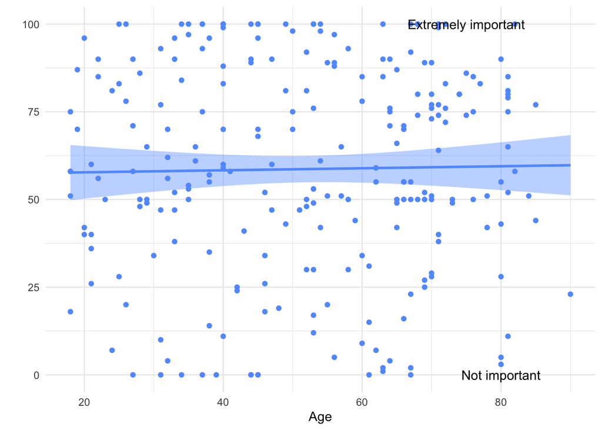